# HW2

Barboni Alessio - Redaelli Francesco

# Part (A)

## Exploratory data analysis and pre-processing

```r
# Data loading
train_csv <- fread("train4final_hw.csv")
test_csv <- fread("test4final_hw.csv")

backup_train <- train_csv
backup_test <- test_csv

# Remove "id" column
train_csv$id <- NULL
test_csv$id <- NULL

# Randomly select and remove 10 training obs (to be used in Part (B))
set.seed(42)
idx <- sample(1:dim(train_csv)[1], 10)
train_aside <- train_csv[idx,1:7041]

train <- train_csv[-idx,1:7040]
test <- test_csv

# Check columns variance
sort(sapply(as.data.frame(train), var))[1:10]
```

```
##       prec.x         rugo      simpson      freq.P1          sfm      shannon
## 0.000000e+00 3.499817e-05 6.109113e-04 4.082934e-03 9.627614e-03 9.922819e-03
##           sh        renyi        sfm.1      time.P2
## 1.523329e-02 2.051008e-02 3.550464e-02 3.725503e-02
```

```r
# Remove "prec.x" column (All values equal (Variance = 0), providing no information)
train$prec.x <- NULL
test$prec.x <- NULL
train_aside$prec.x <- NULL

# Correlation (with the response variable)
corr_mat <- cor(train,y=train_csv$tempo[-idx])[,1]
head(sort(corr_mat,decreasing = FALSE),10)
```

```
##   mel2_t48   mel2_t47  mel2_t170   mel2_t72  mel2_t163  mel2_t134   mel2_t93
## -0.1954373 -0.1917981 -0.1791146 -0.1757601 -0.1756789 -0.1753979 -0.1729340
##  mel2_t171   mel2_t92   mel2_t15
## -0.1726829 -0.1719372 -0.1713344
```

```r
head(sort(corr_mat,decreasing = TRUE),10)
```

```
##    freq.M mel1_t134  mel1_t48  mel1_t40       sem        sd  mel1_t41 mel1_t141
## 0.2251352 0.2034045 0.1978807 0.1940056 0.1898380 0.1898380 0.1884751 0.1850488
##  mel1_t69  mel1_t47
## 0.1847386 0.1841652
```

In an attempt to reproduce the *2020-winning solution*, after an initial shallow pre-processing, we tried several approaches in terms of data selection/manipulation. Different datasets were fed as input to the modelling pipeline:

1. The complete (pre-processed) dataset (in three versions: *original*, *column centered* and *column centered and scaled*). When centering and/or scaling were applied to the training set, the test set columns were transformed according to the training mean and standard deviation

```r
# Centering and scaling
train_mean <- unlist(unname(lapply(train, mean)))
train_sd <- unlist(unname(lapply(train, sd)))

train <- as.data.frame(train)
test <- as.data.frame(test)

for(i in 1:length(train_mean)){
  train[,i] <- (train[,i] - train_mean[i])/train_sd[i]
  test[,i] <- (test[,i] - train_mean[i])/train_sd[i]
}
```

2. A dataset containing the subset of columns whose *correlation* (in absolute value) with the target variable was above a given threshold $k$ (we tried with $k=0.1$ and $k=0.05$)

```r
k_tresh <- 0.1

cols <- names(corr_mat[abs(corr_mat)>=k_tresh])
train <- as.data.frame(train)[,cols]
test <- as.data.frame(test)[,cols]
```

3. The dataset composed of the columns containing information about the *Mel-frequency cepstral coefficients* (the first 6840 columns), as we thought that they could provide an overall picture of the time-evolution of each song, in a homogeneous domain

```r
new_backup_train <- train
new_backup_test <- test

train <- train[,1:6840]
test <- test[,1:6840]
```

The last approach led to the *best results*, and was the one kept for the final draft of the analysis.

## Non-linear dimensionality reduction and modelling

We firstly tackled the problem via a *Python* *scikit-learn* implementation, since we felt more comfortable and quicker in setting up a Cross-Validated tuning pipeline for *dimensionality reduction + SVM modelling* (*code uploaded on Moodle*).

After reproducing the initial pre-processing, we built a pipeline that evaluated the output of a *Kernel Support Vector Machine Regression* ($SVR$) taking as input the result of a *Kernel Principal Component Analysis* ($kPCA$) on the MEL-frequencies restricted dataset.

The pipeline was tuned via a *Grid Search* approach and the result scored in terms of *Cross-Validation Root Mean Squared Error* ($RMSE$). Each combination of the following possible parameters was tried:

- *kPCA Kernel*: $polynomial, \; radial \; basis \; function \; (RBF)$
- *SVR Kernel*: $linear, \; polynomial, \; radial \; basis \; function \; (RBF)$
- *Poly kernel degree*: $[2,3,4,5,7,9,11,13]$
- *SVR C*: $[10^ifor \; i \; in \; range(-3,4)]$
- *SVR Epsilon*: $[10^i \; for \; i \; in \; range(-10,4)]$
- *SVR Gamma*: $[10^i \; for \; i \; in \; range(-10,4)]$
- *kPCA #Components*: $[5,10,15,20,25,30,50,75,100,150,200,All]$

In order to further improve the $RMSE$, a manual optimization (*binary search* over the parameter range) in a neighborhood of the automatically selected parameters was carried out at each step. *In both the Python and R code, only the very final Grid Search step (list of values) is reported*.

The pipeline made up of *kPCA (polynomial kernel, degree = 2, #components = 15)* + *SVR (RBF kernel)* led to the best performance.

We then proceeded to reproduce this pipeline within *R*, selecting only the *top performing model* from *Python*. However, since the *parametrization* adopted by the various tools/libraries did not coincide, and we were aware that different implementations could lead to *inconsistent results* for the same parameters, we preferred to tune all the other *hyperparameters* of the selected models (as well as the number of kPCA components) over again.

```r
# kPCA
ncomp_list <- c(15)

values <- list()
min_rmse <- Inf

for(i in ncomp_list){

  # Fit-transform kPCA on training set
  train_emb <- embed(train, "kPCA", kernel = "polydot", kpar = list(degree = 2), ndim=i)
  new_train <- as.data.frame(getDimRedData(train_emb))

  # Transform test set
  test_emb <- predict(train_emb,test)
  new_test <- as.data.frame(getData(test_emb))

  # Set-up 5-Fold Cross-Validation for SVR
  ctrl <- trainControl(method="cv",number=5)

  # Tune SVR model
  svm.tune <- train(x=new_train,
                    y= train_csv$tempo[-idx],
                    method = "svmRadial",   # RBF kernel
                    tuneGrid = data.frame(sigma=c(0.2),
                                          C=c(4.5)),
                    trControl=ctrl)

  # Store min RMSE and params in i-th step
  values <- append(values, list(list(rmse = min(svm.tune$resample$RMSE), params = svm.tune$bestTune, ncomp = i)))
  print(i)

  # Min RMSE up to i-th step
  min_rmse <- min(min_rmse,min(svm.tune$resample$RMSE))
  print(min_rmse)

}
```

```
## 2022-06-08 17:14:01: Calculating kernel PCA
```

```
## 2022-06-08 17:14:35: Trying to calculate reverse
```

```
## No inverse function.
```

```
## 2022-06-08 17:14:38: DONE
```

```
## [1] 15
## [1] 15.91385
```

```r
# Select parameters leading to min RMSE

min_rmse <- Inf

for(i in 1:length(values)){
  if(values[[i]]$rmse<min_rmse){
    min_rmse <- values[[i]]$rmse
    ncomp <- values[[i]]$ncomp
    knn <- values[[i]]$knn
    id <- i
  }
}

min_rmse
```

```
## [1] 15.91385
```

```r
best_sigma <- values[[id]]$params$sigma
best_C <- values[[id]]$params$C
best_ncomp <- ncomp

# Fit-transform kPCA on training set with best params
train_emb <- embed(train, "kPCA", kernel = "polydot", kpar = list(degree = 2), ndim=best_ncomp)
```

```
## 2022-06-08 17:15:00: Calculating kernel PCA
```

```
## 2022-06-08 17:15:26: Trying to calculate reverse
```

```
## No inverse function.
```

```
## 2022-06-08 17:15:29: DONE
```

```r
new_train <- as.data.frame(getDimRedData(train_emb))

# Transform test set with best params
test_emb <- predict(train_emb,test)
new_test <- as.data.frame(getData(test_emb))

# Tune SVR model with best params
svm.tune <- train(x=new_train,
                    y= train_csv$tempo[-idx],
                    method = "svmRadial",
                    tuneGrid = data.frame(sigma=c(best_sigma),C=c(best_C)))

# Predict on test set
pred_test <- predict(svm.tune, newdata = new_test)
out_df <- data.frame(id = backup_test[,7040], target = pred_test)

write.csv(out_df,"C:\\Users\\Francesco\\Desktop\\submission.csv", row.names = FALSE,quote=FALSE)
```

The $CV RMSE$ on the training set is comparable with the *test set* one (computed by *Kaggle.com*), which is about $17.7$. This could suggest that the model generalizes rather fine to new observations and doesn’t suffer too much from *overfitting*.

However, this accuracy is still *far* from the one achieved by the *2020-winning team*; while we believe that working on a significantly *larger dataset* (as they did) would improve every model performance, we deem that further refined dimensionality reduction and tuning could reduce the error of our model even in the fewer observations settings. In fact, we were aware that by working on a *column-reduced version* of the original dataset at our disposal, we could be neglecting a *significant* amount of information, that might be crucial for regression purposes.

In an attempt to address this issue, we tried implementing an *Isomap dimensionality reduction* step (instead of the *kPCA* one) on the *full uncut dataset*, without further luck in terms of results improvement (the unexecuted pipeline code can be found below).

```r
# Isomap

ncomp_list <- rep(5,35,5)

knn_list <- c(20,30,40,50)

values <- list()

min_rmse <- Inf

for(j in knn_list){
for(i in ncomp_list){

  # Fit-transform Isomap on training set
  train_emb <- embed(new_backup_train, "Isomap", ndim=i, knn=j)
  new_train <- as.data.frame(getDimRedData(train_emb))

  # Transform test set
  test_emb <- predict(train_emb,new_backup_test)
  new_test <- as.data.frame(getData(test_emb))

  # Set-up 5-Fold Cross-Validation for SVR
  ctrl <- trainControl(method="cv",number=5)

  # Tune SVR model
  svm.tune <- train(x=new_train,
                    y= train_csv$tempo[-idx],
                    method = "svmRadial",   # RBF kernel
                    tuneGrid = data.frame(sigma=c(0.01),C=c(0.001,0.01,0.1,1,10,100,200)),
                    trControl=ctrl)

  # Store min RMSE and params in i-th step
  values <- append(values, list(list(rmse = min(svm.tune$resample$RMSE), params = svm.tune$bestTune, ncomp = i, knn=j)))

  print(j)
  print(i)

  # Min RMSE up to i-th step
  min_rmse <- min(min_rmse,min(svm.tune$resample$RMSE))
  print(min_rmse)

}
}

min_rmse <- Inf

for(i in 1:length(values)){
  if(values[[i]]$rmse<min_rmse){
    min_rmse <- values[[i]]$rmse
    ncomp <- values[[i]]$ncomp
    knn <- values[[i]]$knn
    id <- i
  }
}
min_rmse
best_sigma <- values[[id]]$params$sigma
best_C <- values[[id]]$params$C
best_ncomp <- ncomp
best_knn <- knn

# Fit-transform Isomap on training set with best params
train_emb <- embed(new_backup_train, "Isomap", ndim=best_ncomp)
new_train <- as.data.frame(getDimRedData(train_emb))

# Transform test set with best params
test_emb <- predict(train_emb,new_backup_test)
new_test <- as.data.frame(getData(test_emb))

# Tune SVR model with best params
svm.tune <- train(x=new_train,
                    y= train_csv$tempo[-idx],
                    method = "svmRadial",
                    tuneGrid = data.frame(sigma=c(best_sigma),C=c(best_C)))

# Predict on test set
pred_test <- predict(svm.tune, newdata = new_test)
out_df <- data.frame(id = new_backup_test[,7040], target = pred_test)

#write.csv(out_df,"C:\\Users\\Francesco\\Desktop\\submission.csv", row.names = FALSE,quote=FALSE)
```

The final pipeline achieving the best *test set* $RMSE$ was made up of:

- *kPCA (Dimensionality Reduction)*: ${Kernel = polynomial, \; degree = 2, \; n\_components = 15}$
- *SVR (Model)*: ${Kernel = RBF, \; C = 4.5, \; sigma = 0.2}$

It should be pointed out that both *theory* and *practical experience* highlight how parameters tuning *significantly* affects model performances. While we were working, we noticed that even a *slight* change in the hyperparameters value could bring the $RMSE$ up or down by several points. Although we tried a *fairly* large amount of possible values, we are confident that an even more *meticulous/informed search* could lead to *substantial improvements*, possibily by employing different *dimensionality reduction techniques* and/or *kernels*.

# Part (B)

```r
# Split Conformal Prediction Algorithm

SCPA <- function(D_n,D_n_y,alpha,cv_sigma,cv_C){

  n <- dim(D_n)[1]

  # Random split
  set.seed(42)
  idx <- sample(1:n,5)
  D_1 <- as.data.frame(D_n[idx,], columns = names(D_n))
  D_1_y <- D_n_y[idx]
  D_2 <- as.data.frame(D_n[-idx,], columns = names(D_n))
  D_2_y <- D_n_y[-idx]

  # Training
  svm.tune <- train(x = D_1, y = D_1_y,
                  method = "svmRadial",tuneGrid=data.frame(sigma=c(cv_sigma),C=c(cv_C)))

  # Predict and evaluate
  pred <- predict(svm.tune, newdata = D_2)

  residuals <- abs(D_2_y-pred)

  # Compute k and d
  k <- ceiling((n/2+1)*(1-alpha))
  d <- sort(residuals)[k]

  return(list(model = svm.tune, d = d))
}

C_split <- function(D_n,model,d){

  n <- dim(D_n)[1]

  C_split_x <- list()

  for(i in 1:n){

    f_hat <- predict(model, newdata = D_n[i,])
    C_split_x <- append(C_split_x, list(list(L = f_hat - d, U = f_hat + d)))
  }

  return(C_split_x)
}

alpha <- 0.2
```

```r
# Best CV parameters
best_cv_sigma <- 0.2
best_cv_C <- 4.5
best_ncomp <- 15

new_train_aside <- train_aside
train_aside_y <- train_aside$tempo
new_train_aside <- new_train_aside[,1:6840]

# Fit kPCA on part (A) training set
train_emb <- embed(train, "kPCA", kernel = "polydot", kpar = list(degree = 2), ndim=best_ncomp)
```

```
## 2022-06-08 17:16:22: Calculating kernel PCA
```

```
## 2022-06-08 17:16:49: Trying to calculate reverse
```

```
## No inverse function.
```

```
## 2022-06-08 17:16:51: DONE
```

## Training

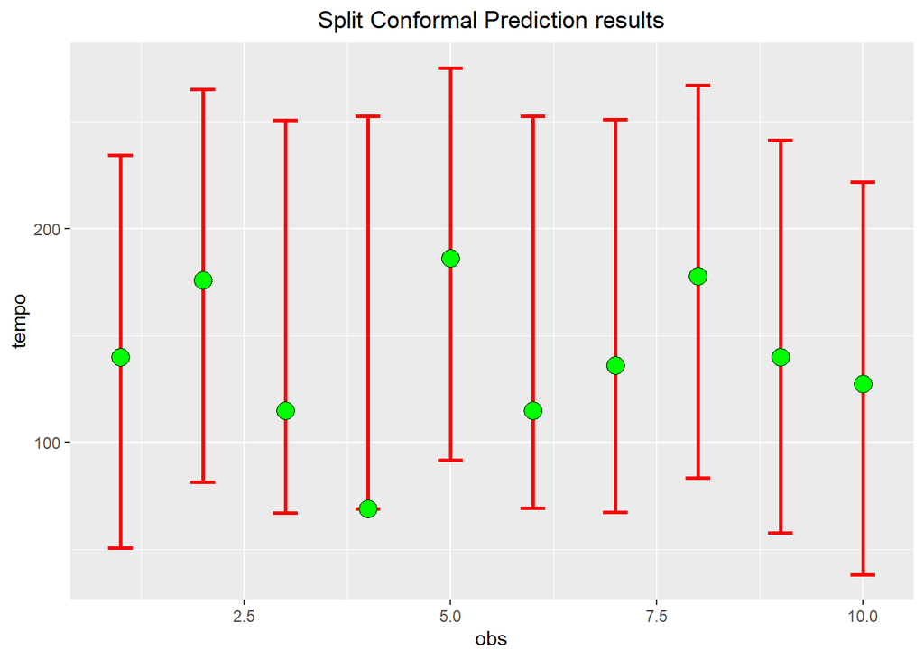

```r
# Transform training set
train_aside_emb <- predict(train_emb,new_train_aside)
kpca_train_aside <- as.data.frame(getData(train_aside_emb))

D_n_train <- kpca_train_aside

cp_model <- SCPA(D_n_train,train_aside_y,alpha,best_cv_sigma,best_cv_C)

pred_sets <- C_split(D_n_train,cp_model$model,cp_model$d)

n_pred <- length(pred_sets)

L_vec <- rep(NA,n_pred)
U_vec <- rep(NA,n_pred)

for(i in 1:n_pred){
  temp <- pred_sets[[i]]
  L_vec[i] <- temp$L
  U_vec[i] <- temp$U
}

obs <- 1:10
tempo <- train_aside_y

mydata <- data.frame(obs,tempo)

ggplot(mydata, aes(x=obs, y=tempo)) +
    geom_errorbar(width=.3, aes(ymin=L_vec, ymax=U_vec), col = "red", size = 1) +
    geom_point(shape=21, size=4.5, fill="green") +
    ggtitle("Split Conformal Prediction results") +
    theme(plot.title = element_text(hjust = 0.5))
```

```r
cp_model$d
```

```
## [1] 91.77029
```

is larger than *half* the range of the tempo variable in the training set

```r
range(train_csv$tempo)
```

```
## [1]  63 200
```

we believe such predictive sets might not be very informative.

## Test

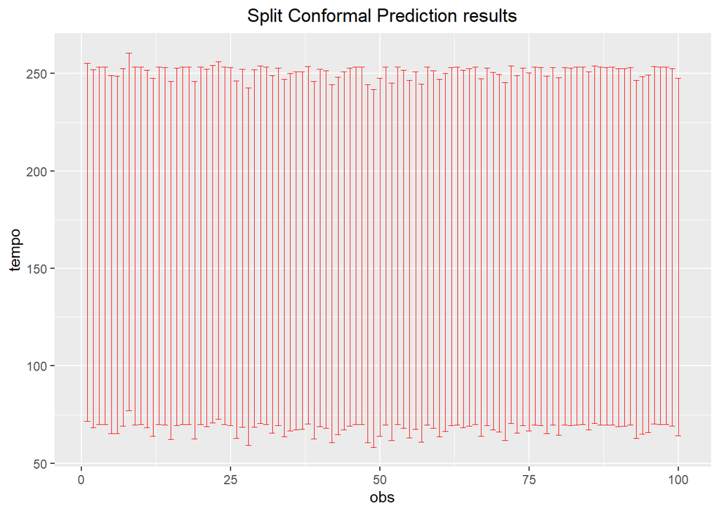

```r
idx <- sample(1:dim(test)[1], 100)
test_aside <- test[idx,1:6840]

# Transform test set
test_aside_emb <- predict(train_emb,test_aside)
D_n_test <- as.data.frame(getData(test_aside_emb))

pred_sets <- C_split(D_n_test,cp_model$model,cp_model$d)

n_pred <- length(pred_sets)

L_vec <- rep(NA,n_pred)
U_vec <- rep(NA,n_pred)

for(i in 1:n_pred){
  temp <- pred_sets[[i]]
  L_vec[i] <- temp$L
  U_vec[i] <- temp$U
}

obs <- 1:100
tempo <- 1:100

mydata <- data.frame(obs,tempo)

ggplot(mydata, aes(x=obs,y=tempo)) +
    geom_errorbar(width=1, aes(ymin=L_vec, ymax=U_vec), col = "red", size = 0.1) +
    ggtitle("Split Conformal Prediction results") +
    ylim(min(L_vec),max(U_vec)) +
    theme(plot.title = element_text(hjust = 0.5))
```